# Predicting Quantified Self Movement using Maching Learning

cabruce

November 17, 2015

# Executive Summary

The Quantified Self is a movement to combine technology and data acquisition to quantify a person’s daily life. Examples of such measures are food consumed, sleep patterns, and heart rate. These measured are quantified using wearable sensors. Commercial examples include a Nike Fuelband, an Apple Watch, and a Fitbit. These wearables are accompanyied by software to help the wearer track his or her measurements over time.

# Results

The packaged used in the analysis are as follows:

```r
library(caret)
library(rpart)
library(rpart.plot)
library(randomForest)
library(corrplot)
```

## Import and clean data

Assuming the data has already been downloaded to the working directory, the raw data is imported and cleaned. Columns containing NA values were removed, and predictors that are outside the prediction were also removed. The final datasets include 53 predictors including classe.

```r
trainCSV <- read.csv("./pml-training.csv")
testCSV <- read.csv("./pml-testing.csv")
```

```r
trainCSV <- trainCSV[, colSums(is.na(trainCSV)) == 0]
testCSV <- testCSV[, colSums(is.na(testCSV)) == 0]
```

```r
classe <- trainCSV$classe
trainExtra <- grepl("^X|timestamp|window", names(trainCSV))
trainCSV <- trainCSV[, !trainExtra]
trainFinal <- trainCSV[, sapply(trainCSV, is.numeric)]
trainFinal$classe <- classe
testExtra <- grepl("^X|timestamp|window", names(testCSV))
testCSV <- testCSV[, !testExtra]
testFinal <- testCSV[, sapply(testCSV, is.numeric)]
```

The training dataset contains both pure (70%) and validation data (30%), so a data partition needs to be made.

```r
set.seed(85022)
inTrain <- createDataPartition(trainFinal$classe, p=0.70, list=F)
trainData <- trainFinal[inTrain, ]
testData <- trainFinal[-inTrain, ]
```

## Data Modeling

The predictive algorithm was constructed using the “Random Forest” technique, which better takes into account the correlation between predictors, as well as the “five-fold cross-validation”" techique.

A visualization of these correlations can be seen in Figure 1.

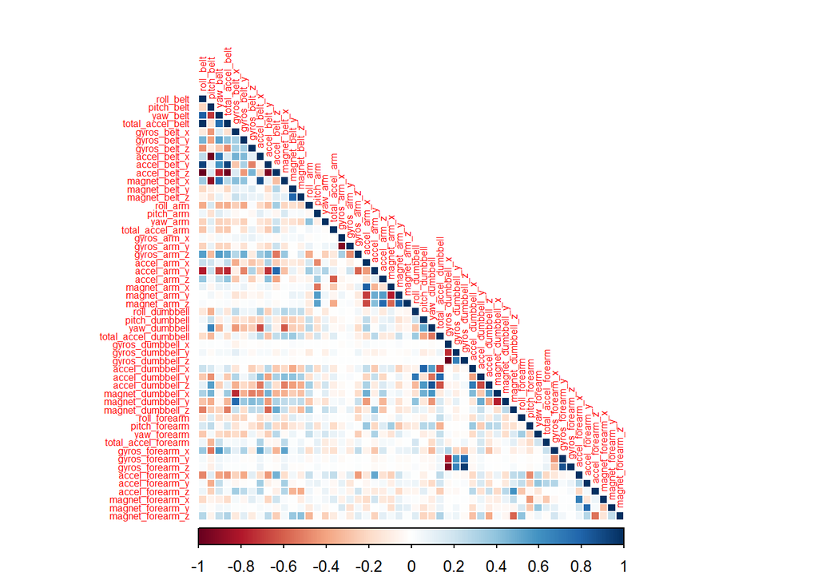

```r
corrPlot <- cor(trainData[, -length(names(trainData))])
corrplot(corrPlot, method="color", type="lower", tl.cex = .5)
```

```r
controlRF <- trainControl(method="cv", 5)
modelRF <- train(classe ~ ., data=trainData, method="rf", trControl=controlRF, ntree=250)
modelRF
```

```
## Random Forest
##
## 13737 samples
##    52 predictor
##     5 classes: 'A', 'B', 'C', 'D', 'E'
##
## No pre-processing
## Resampling: Cross-Validated (5 fold)
## Summary of sample sizes: 10990, 10990, 10990, 10988, 10990
## Resampling results across tuning parameters:
##
##   mtry  Accuracy   Kappa      Accuracy SD  Kappa SD
##    2    0.9911187  0.9887646  0.002101518  0.002659269
##   27    0.9907549  0.9883047  0.001813008  0.002293882
##   52    0.9858775  0.9821339  0.002488009  0.003147805
##
## Accuracy was used to select the optimal model using  the largest value.
## The final value used for the model was mtry = 2.
```

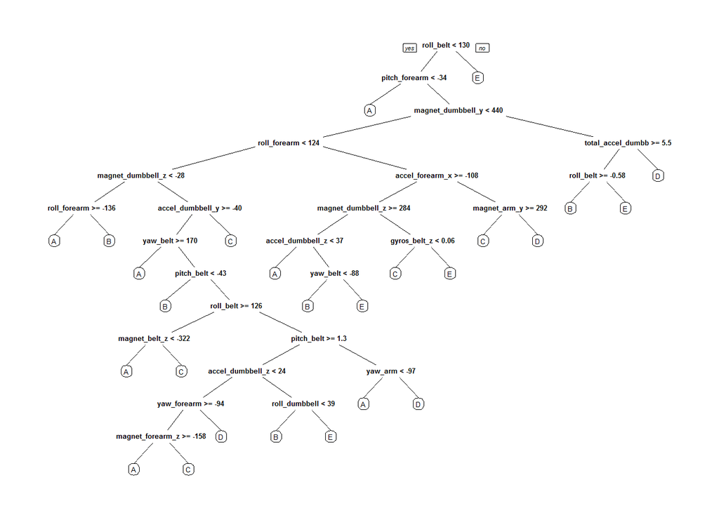

```r
treeModel <- rpart(classe ~ ., data=trainData, method="class")
prp(treeModel)
```

The accuracy and error of the model were estimated using the validation portion of the dataset.

```r
predictRF <- predict(modelRF, testData)
confusionMatrix(testData$classe, predictRF)
```

```
## Confusion Matrix and Statistics
##
##           Reference
## Prediction    A    B    C    D    E
##          A 1673    1    0    0    0
##          B    8 1131    0    0    0
##          C    0   15 1011    0    0
##          D    0    0   10  952    2
##          E    0    0    1    3 1078
##
## Overall Statistics
##
##                Accuracy : 0.9932
##                  95% CI : (0.9908, 0.9951)
##     No Information Rate : 0.2856
##     P-Value [Acc > NIR] : < 2.2e-16
##
##                   Kappa : 0.9914
##  Mcnemar's Test P-Value : NA
##
## Statistics by Class:
##
##                      Class: A Class: B Class: C Class: D Class: E
## Sensitivity            0.9952   0.9861   0.9892   0.9969   0.9981
## Specificity            0.9998   0.9983   0.9969   0.9976   0.9992
## Pos Pred Value         0.9994   0.9930   0.9854   0.9876   0.9963
## Neg Pred Value         0.9981   0.9966   0.9977   0.9994   0.9996
## Prevalence             0.2856   0.1949   0.1737   0.1623   0.1835
## Detection Rate         0.2843   0.1922   0.1718   0.1618   0.1832
## Detection Prevalence   0.2845   0.1935   0.1743   0.1638   0.1839
## Balanced Accuracy      0.9975   0.9922   0.9931   0.9972   0.9987
```

```r
postResample(predictRF, testData$classe)
```

```
##  Accuracy     Kappa
## 0.9932031 0.9914009
```

```r
1 - as.numeric(confusionMatrix(testData$classe, predictRF)$overall[1]) #error measure
```

```
## [1] 0.006796941
```

## Test Data

```r
predict(modelRF, testFinal[, -length(names(testFinal))])
```

[output not shown]